# DATA 300 3 Homework 3 Solution

Aadarsha Gopala Reddy

October 18, 2022

# 1. Setup

- Install and Import the kidney disease dataset as an object in R.
- Load the following packages: `tidyverse, caret, rpart,` and `rpart.plot`.

> `install.packages()` Installs packages from CRAN.

> `library()` Loads any packages.

> `read.csv()` Reads the csv file.

```r
library(tidyverse)
library(caret)
```

```r
library(rpart)
library(rpart.plot)

kidney <- read.csv("kidney_disease.csv")
```

# 2. Test-Train Split

Split the dataset into a testing and training dataset.

- Selection into the testing and training datasets should be random.
- Each patient should appear in either the testing or training dataset, but no patient should appear in both.
- Your training dataset should have more observations than your testing dataset. Aim to have between 60 and 70% of the observations in the training dataset.

Hint: you might do this using either the sample() function or the rbinom() function.

> `set.seed()` Sets the seed for the random number generator.

> `sample()` Samples a vector of numbers.

> `setdiff()` Returns the difference between two vectors.

```r
set.seed(1)
train <- sample(1:nrow(kidney), size = 0.7 * nrow(kidney))
test <- setdiff(1:nrow(kidney), train)
```

# 3. Train K-Nearest Neighbors

Train a K-Nearest Neighbors algorithm to predict nephritis.

- When training the model, use the training dataset only.
- You may need to change how the variables in the dataset are coded to train the algorithm.
- Use the train() function in the caret package.

> `as.factor()` Converts a vector to a factor.

> `train()` Trains a model.

```r
# change the coding of the variables
kidney$nausea <- as.factor(kidney$nausea)
kidney$backpain <- as.factor(kidney$backpain)
kidney$pushing <- as.factor(kidney$pushing)
kidney$pain <- as.factor(kidney$pain)
kidney$itching <- as.factor(kidney$itching)
kidney$nephritis <- as.factor(kidney$nephritis)

# train the model
knn_model <- train(nephritis ~ ., data = kidney[train, ], method = "knn")

# print the model
knn_model
```

```
## k-Nearest Neighbors
##
## 84 samples
##  6 predictor
##  2 classes: 'no', 'yes'
##
## No pre-processing
## Resampling: Bootstrapped (25 reps)
## Summary of sample sizes: 84, 84, 84, 84, 84, 84, ...
## Resampling results across tuning parameters:
##
##   k  Accuracy   Kappa
##   5  0.9834091  0.9660500
##   7  0.9677500  0.9343441
##   9  0.9466220  0.8918256
##
## Accuracy was used to select the optimal model using the largest value.
## The final value used for the model was k = 5.
```

Interpret the output of the trained algorithm. What value of K works best for predicting nephritis? What is the predictive accuracy for that value of K?

> **The optimal value of K is 5 which gives an accuracy of 98.34091%.**

# 4. Test K-Nearest Neighbors

Test the algorithm you trained in the previous section using your testing dataset.

- Generate predictions for the patients in the testing dataset using the `predict()` function.
- You may find the `confusionMatrix()` function helpful for comparing the predictions to the actual outcomes.

> `predict()` Generates predictions for a model.

> `confusionMatrix()` Generates a confusion matrix.

```r
# predict the outcomes
knn_pred <- predict(knn_model, kidney[test, ])

# compare the predictions to the actual outcomes
confusionMatrix(knn_pred, kidney$nephritis[test])
```

```
## Confusion Matrix and Statistics
##
##           Reference
## Prediction no yes
##        no  23   0
##        yes  0  13
##
##                Accuracy : 1
##                  95% CI : (0.9026, 1)
##     No Information Rate : 0.6389
##     P-Value [Acc > NIR] : 9.893e-08
##
##                   Kappa : 1
##
##  Mcnemar's Test P-Value : NA
##
##             Sensitivity : 1.0000
##             Specificity : 1.0000
##          Pos Pred Value : 1.0000
##          Neg Pred Value : 1.0000
##              Prevalence : 0.6389
##          Detection Rate : 0.6389
##    Detection Prevalence : 0.6389
##       Balanced Accuracy : 1.0000
##
##        'Positive' Class : no
##
```

What is the predictive accuracy of the algorithm in the testing data?

> **The predictive accuracy of the k-nearest neighbors algorithm in the testing data is 100%.**

# 5. Train A Decision Tree

Train a decision tree to predict nephritis.

- When training the model, use the training dataset only.
- Use the rpart() function in the rpart package.

> `rpart()` Trains a decision tree.

```r
# train the model
tree_model <- rpart(nephritis ~ ., data = kidney[train, ], method = "class")

# print the model
tree_model
```

```
## n= 84
##
## node), split, n, loss, yval, (yprob)
##       * denotes terminal node
##
## 1) root 84 37 no (0.5595238 0.4404762)
##   2) temp< 37.95 41  0 no (1.0000000 0.0000000) *
##   3) temp>=37.95 43  6 yes (0.1395349 0.8604651) *
```

# 6. View the Decision Tree

Use the rpart.plot() function to view the decision tree that you trained in the previous question. Interpret this tree. What symptoms is the algorithm using to predict nephritis?

> `rpart.plot()` Plots a decision tree.

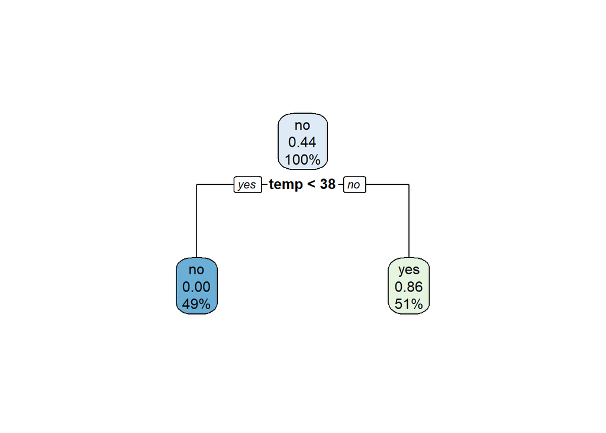

```r
# plot the tree
rpart.plot(tree_model)
```

# 7. Test the Decision Tree

Test the decision tree that you trained in question 5 using your testing dataset. Again, you can generate predictions using the predict() function.

> `predict()` Generates predictions for a model.

```r
# predict the outcomes
tree_pred <- predict(tree_model, kidney[test, ], type = "class")

# compare the predictions to the actual outcomes
confusionMatrix(tree_pred, kidney$nephritis[test])
```

```
## Confusion Matrix and Statistics
##
##           Reference
## Prediction no yes
##        no  19   0
##        yes  4  13
##
##                Accuracy : 0.8889
##                  95% CI : (0.7394, 0.9689)
##     No Information Rate : 0.6389
##     P-Value [Acc > NIR] : 0.0007443
##
##                   Kappa : 0.7743
##
##  Mcnemar's Test P-Value : 0.1336144
##
##             Sensitivity : 0.8261
##             Specificity : 1.0000
##          Pos Pred Value : 1.0000
##          Neg Pred Value : 0.7647
##              Prevalence : 0.6389
##          Detection Rate : 0.5278
##    Detection Prevalence : 0.5278
##       Balanced Accuracy : 0.9130
##
##        'Positive' Class : no
##
```

What is the predictive accuracy of the decision tree in the testing data?

> **The predictive accuracy of the decision tree in the testing data is 88.89%.**

# 8. Compare the Algorithms

Which of your two algorithms predicts nephritis more accurately?

> **The k-nearest neighbors algorithm predicts nephritis more accurately than the Decision Tree Algorithm. Although, for most seed values, both algorithms predict with 100% accuracy for this dataset.**